# Variable coding ⑪ — why models differ, and a cheap reliable extractor

Across 22 models coding the same 30 posts into a fixed 37-field schema, the raw exact-match disagreement looked alarming (~28% token-Jaccard). This notebook answers three questions and turns the answer into a **deployable extractor**:

1. **Are the mistakes predictable?** Yes — they're overwhelmingly *how much* a model extracts, not *what* it decides, and *which cell* is coded matters far more than *which model* codes it.
2. **Is the disagreement even real?** On the hardest cells, models agree with **each other** while disagreeing with the gold — so a majority of that 'error' is gold idiosyncrasy, not a model miss.
3. **What's the reliable, cheap recipe?** Three cheap cross-lab models, consensus-gated, with a strong judge panel for the contested minority — but the routing must be **tier-aware**, because the same consensus that is ~5× better than a single model on factual fields is *worse* than one model on the interpretive fields.

*All figures are recomputed from the coding runs, the Opus semantic verdicts, and a fresh model-vs-model semantic judge over the cheap cross-lab trio + grok-4.5.*

*(loaded — 22 models × 30 posts × 37 fields; 4,237 model-vs-gold semantic verdicts; cheap trio = deepseek-v4-flash, gemini-3.1-flash-lite, gpt-5-mini)*

## 1. The disagreement is predictable and structural

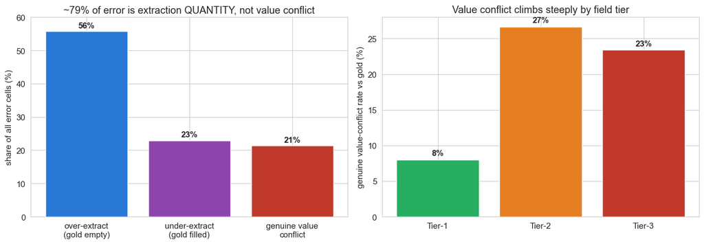

**79% of all error is over/under-extraction** (1,944 over, 801 under across the roster); only **21%** is a genuine value conflict. Over/under lean is forecastable from a model's fill-rate — verbose models over-fill, terse models under-fill — so it's a stable, correctable trait, not noise. And the genuine conflicts pile up by tier: **Tier-1 8% → Tier-2 27% → Tier-3 23%**. The tier a field lives in predicts its reliability far better than the model does — which is exactly what the extractor below exploits.

## 2. Is the disagreement even real? — the blind-spot cross-check

The sharpest test of whether that error is *model* error or *gold* idiosyncrasy: take the cells where **≥50% of the 22 models disagree with the Opus gold**, and ask whether those models agree **with each other**. If they do, the gold is the outlier, not the models. We judged this with a fresh Opus semantic pass over four models (the three cheap cross-lab producers + grok-4.5).

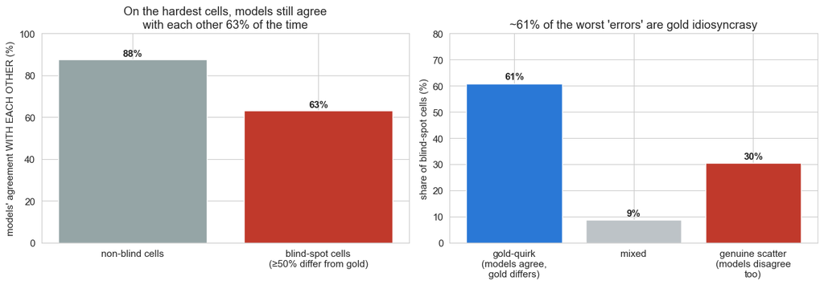

On blind-spot cells the four models still agree with **each other 63%** of the time (vs 88% elsewhere), and **61% of those cells are gold-quirk** — the models converge on a reading the gold doesn't share. So the raw diff-rate *overstates* true model error: a large slice of it is the gold being sparse, picking one of several valid readings, or coding at a different granularity. The genuine model-miss floor sits **below** the headline number (n=23 blind-spot cells — directional, not precise).

**Gold-quirk examples — models converge, gold differs**

| tier | field | gold value | what the models say |
| --- | --- | --- | --- |
| Tier-2 | activity_level | ['bedbound', 'unable to work for over a year'] | deepseek-v4-flash:['limited'] · gemini-3.1-flash-lite:['housebound'] |
| Tier-2 | activity_level | ['completely on sick leave', 'fully recovered (one commenter)', 'no si | deepseek-v4-flash:['fully recovered', 'housebound', · grok-4.5:['fully recovered'] |
| Tier-2 | symptom_trajectory | ['no signs of improvement', 'gradually worsened'] | deepseek-v4-flash:['recovered', 'no improvement', 'g · gpt-5-mini:['gradually worsened until complet |
| Tier-3 | healthcare_system | ['alberta (canada)', 'another canadian province'] | gemini-3.1-flash-lite:['us (massachusetts)', 'canada (al · gpt-5-mini:['us — massachusetts (brigham and |
| Tier-1 | symptom_duration | ['6 months (new arm symptom)', 'since day one / beginning (arm weaknes | deepseek-v4-flash:['6 months (since onset of new sym · gpt-5-mini:['new right arm symptom occurred a |
| Tier-2 | conditions | ['mcas', 'severe anhedonia', 'consummatory anhedonia', 'emotional blun | deepseek-v4-flash:['mcas', 'anhedonia', 'seasonal al · gemini-3.1-flash-lite:['mcas', 'anhedonia', 'consummator |

## 3. The cheap extractor — 3 cross-lab models, consensus-gated

The deployable recipe: run **three cheap models from three different labs** (`deepseek-v4-flash` · `gemini-3.1-flash-lite` · `gpt-5-mini`) and gate on **cross-lab agreement**. A cell where ≥2 of them agree (semantically) is auto-accepted; all-three-empty is auto-accepted as absent; anything else escalates to a judge. The headline: **on factual (Tier-1) fields, three cheap models beat every single model — including the best one.**

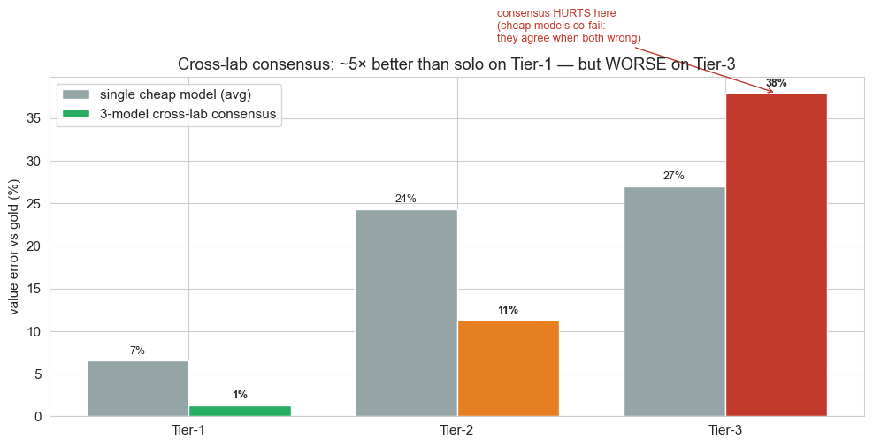

- **Tier-1 (21 factual fields): consensus 1.3% vs solo 7% — ~5× lower**, and below even grok-4.5 solo (4%). Three $0.10–0.25 models cross-checking beat one $2 model. This is where consensus earns its keep.

- **Tier-2 (7 list fields): consensus 11% vs solo 24% — ~2× lower.** Helps, but still leaks — the cheap producers co-fail on partial lists (agree on the same incomplete set).

- **Tier-3 (9 interpretive fields): consensus 38% vs solo 27% — consensus is *worse*.** When two cheap models agree on an interpretive field they are disproportionately **co-failing** (or the gold is quirky, §2). Agreement is anti-correlated with correctness here, so the gate *selects for* shared error. **Never auto-accept cheap consensus on Tier-3.** (n=29 value cells — wide bar, but the direction matches the co-failure mechanism.)

## 4. Coverage, escalation, and the judge panel

How much of the work the cheap trio clears on its own, and what's left for the judge. The escalated cells — where the cheap models *don't* reach cross-lab agreement — are exactly the hard, contested ones, which is precisely where the expensive judge budget should go.

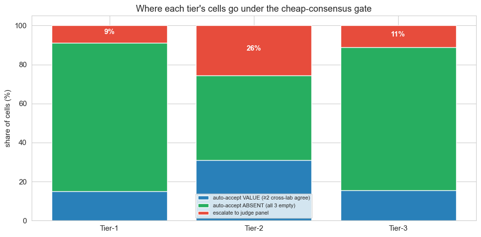

Under the plain gate the trio auto-resolves **87%** of cells and escalates 13%. But because Tier-3 value-consensus can't be trusted (§3), the **recommended tiered policy** additionally routes *all* populated Tier-3 cells to the judge. Net: **auto-resolve 84% of cells at 95.0% accuracy, judge panel on 16%** (182 of 1110 cells).

**The judge panel must be strong, not cheap.** The escalated cells are the interpretive/contested ones where cheap models co-fail — an earlier cheap-judge test found free judges are either yes-men (~61% false-confirm) or too slow, so a cheap panel would rubber-stamp the co-failures. Use a strong adjudicator (grok-4.5 at 10% solo, or Opus) — and for Tier-3, where even the gold is soft, a 2-of-{Opus, grok, human} panel.

## 5. The recommended pipeline

**Tier-aware extraction pipeline**

| stage | rule | note |
| --- | --- | --- |
| Tier-1 (21 factual fields) | 3-model cross-lab consensus → auto-accept | 1% error; escalate only the ~9% contested |
| Tier-2 (7 list fields) | consensus, but require all-3 or escalate contested | 11% residual leak → spot-check with judge |
| Tier-3 (9 interpretive) | consensus for ABSENCE only; route ALL values to judge panel | cheap consensus worse than solo here — do not trust it |
| Judge panel | strong adjudicator (grok-4.5 / Opus); 2-of-3 w/ human on Tier-3 | fires on ~16% of cells — the hard minority |
| Single-model fallback | grok-4.5 if only one model affordable | 10.3% overall; but the trio strictly dominates it on Tier-1/2 |

## Limitations

- **30 posts.** Tier-3 value-consensus rests on n=29 cells — the "consensus worse than solo" direction is robust to the mechanism (co-failure + gold-quirk both push it), but the 38% point value has a wide bar. Scale the trio + judge run on a larger sample before pinning tier thresholds.
- **Measured against Opus-gold**, which itself disagrees with the Luna/Sol golds 13–16% and over-selects one reading on interpretive fields (§2 shows a majority of the worst "errors" are gold idiosyncrasy). Tier-1 accuracy is trustworthy; Tier-3 "error" is partly a gold artifact, which is *another* reason to escalate it.
- **"Agree" = Opus semantic-equivalence** over the cheap trio's outputs. A different judge could shift the consensus set slightly; the tier ordering is stable, the second decimal is not.
- **Cost is illustrative** — cheap producers ~$0.10–0.25/1M vs Opus $5/1M; the judge-call rate (~16%) is the real cost driver, and it's dominated by Tier-2/3. Actual $/1k-posts depends on batch sizing.
- Measures reliability of an extraction step against a model gold, not any treatment effect. Not medical advice.

**Provenance**

| item | value |
| --- | --- |
| producers | deepseek-v4-flash, gemini-3.1-flash-lite, gpt-5-mini |
| strong ref / judge | grok-4.5 |
| gold | claude-opus-4.8 |
| semantic judge | anthropic/claude-opus-4.8 (equivalence) |
| posts × fields | 30 × 37 |
| method | cross-lab consensus gate + tier-differentiated escalation |

Measures an extraction step’s reliability against a model gold, not treatment effects. Not medical advice.